# ANOVA.Дисперсионный анализ

© Alexander Doynikov,dep. CS, MSU

April 7, 2023

### ANOVA.Дисперсионный анализ.

Дисперсионный анализ — метод в математической статистике, направленный на поиск зависимостей в экспериментальных данных путём исследования значимости различий в средних значениях. Суть дисперсионного анализа сводится к изучению влияния одной или нескольких независимых переменных, обычно именуемых факторами, на зависимую переменную. В зависимости от типа и количества переменных различают:

однофакторный и многофакторный дисперсионный анализ (одна или несколько независимых переменных);

одномерный и многомерный дисперсионный анализ (одна или несколько зависимых переменных);

дисперсионный анализ с повторными измерениями (для зависимых выборок);

дисперсионный анализ с постоянными факторами, случайными факторами, и смешанные модели с факторами обоих типов.

Математическая модель дисперсионного анализа представляет собой частный случай основной линейной модели. Пусть с помощью методов $A_{j},(1\leq j\leq m)$ производится измерение нескольких параметров $x_{i},(1\leq i\leq n)$ , чьи точные значения — $\mu _{i},(1\leq i\leq n)$ В таком случае результаты измерений различных величин различными методами можно представить как:
$$x_{i,j}=\mu_i+a_{i,j}+\epsilon_{i,j}$$
Здесь

$a_{i,j}$- систематическая ошибка измерения $i$-го параметра в группе по методу $A_{j}$;

$\epsilon_{i,j}$-случайная ошибка измерения $i$-го параметра по методу $A_{j}$.

$\mu _{i}$ — точное значение $i$-го параметра.

В качестве примера возьмем классический пример времени свертоваемости крови при различной диете из библиотеки faraway

```r
Sys.getlocale()
```

```
## [1] "LC_COLLATE=English_United States.1252;LC_CTYPE=English_United States.1252;LC_MONETARY=English_United States.1252;LC_NUMERIC=C;LC_TIME=English_United States.1252"
```

```r
Sys.setlocale("LC_ALL", "russian_Russia.1251")
```

```
## [1] "LC_COLLATE=Russian_Russia.1251;LC_CTYPE=Russian_Russia.1251;LC_MONETARY=Russian_Russia.1251;LC_NUMERIC=C;LC_TIME=Russian_Russia.1251"
```

```r
library(faraway)
data(coagulation)
head(coagulation)
```

```
##   coag diet
## 1   62    A
## 2   60    A
## 3   63    A
## 4   59    A
## 5   63    B
## 6   67    B
```

Сначала просто изобразим данные наблюдений

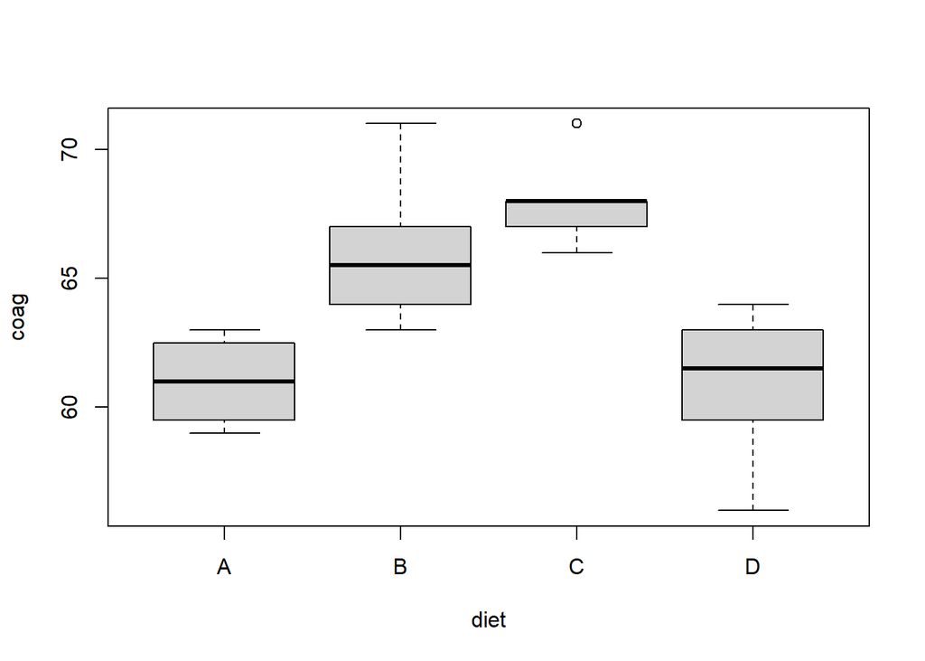

```r
plot(coag~diet, data=coagulation)
```

На рисунке толстые горизонтальные линиии это оценка медианы по группе. Нижняя соответственно верхняя граница прямоугольника это квартили ниже нижней лежит 25% массы распределения, выше верхней также 25% распределения.И так называемые “усы”- оценки максимума и минимума в соответствии с распределением. Точки, которые выпадают за оценки экстремумом отображаются точками - это называют выбросами.  
Оценим простую регрессионную модель

```r
g <- lm(coag ~ diet, coagulation)
summary(g)
```

```
##
## Call:
## lm(formula = coag ~ diet, data = coagulation)
##
## Residuals:
##    Min     1Q Median     3Q    Max
##  -5.00  -1.25   0.00   1.25   5.00
##
## Coefficients:
##              Estimate Std. Error t value Pr(>|t|)
## (Intercept) 6.100e+01  1.183e+00  51.554  < 2e-16 ***
## dietB       5.000e+00  1.528e+00   3.273 0.003803 **
## dietC       7.000e+00  1.528e+00   4.583 0.000181 ***
## dietD       2.991e-15  1.449e+00   0.000 1.000000
## ---
## Signif. codes:  0 '***' 0.001 '**' 0.01 '*' 0.05 '.' 0.1 ' ' 1
##
## Residual standard error: 2.366 on 20 degrees of freedom
## Multiple R-squared:  0.6706, Adjusted R-squared:  0.6212
## F-statistic: 13.57 on 3 and 20 DF,  p-value: 4.658e-05
```

Значение р-значение F-статистики маленькое, говорит нам о том, что существует различие в группах.

Посмотрим на таблицу дисперсионного анализа,позволяющую проверить гипотезу о том, что все средние по группам равны между собой
$$H_0:\mu_1=\mu_2=...\mu_k$$
.

т.е. наблюдаемые различия между групповыми средними несущественны и случайны. Альтернативная гипотеза, соответственно, утверждает, что различия все же не случайны. Чтобы принять или отклонить нулевую гипотезу, нам надо сравнить межгрупповую VARb и внутригрупповую VARw дисперсии. Обе эти величины по-своему оценивают дисперсию генеральной совокупности, и при верной нулевой гипотезе их отношение находится недалеко от 1, т.е. внутригрупповая и межгрупповая дисперсии не различаются.

```r
anova(g)
```

```
## Analysis of Variance Table
##
## Response: coag
##           Df Sum Sq Mean Sq F value    Pr(>F)
## diet       3    228    76.0  13.571 4.658e-05 ***
## Residuals 20    112     5.6
## ---
## Signif. codes:  0 '***' 0.001 '**' 0.01 '*' 0.05 '.' 0.1 ' ' 1
```

Посмотрим на внутригрупповые сумму квадратов

```r
  (anovag_Sum_Sq_2 <- anova(g)$"Sum Sq"[2])
```

```
## [1] 112
```

Теперь посмотрим на межгрупповую сумму квадратов

```r
  (anovag_Sum_Sq_1 <- anova(g)$"Sum Sq"[1])
```

```
## [1] 228
```

Внутригрупповая и межгрупповая дисперсии различы. Таким образом гипотеза о равенстве групповых средних скорее всего будет отвергнута.

Действительно р-значение для проверки этой гипотезы равно

```r
  (anovag_PValue<- anova(g)$"Pr(>F)"[1])
```

```
## [1] 4.658471e-05
```

Оценим модель без константы

```r
gi <- lm(coag ~ diet -1, coagulation)
summary(gi)
```

```
##
## Call:
## lm(formula = coag ~ diet - 1, data = coagulation)
##
## Residuals:
##    Min     1Q Median     3Q    Max
##  -5.00  -1.25   0.00   1.25   5.00
##
## Coefficients:
##       Estimate Std. Error t value Pr(>|t|)
## dietA  61.0000     1.1832   51.55   <2e-16 ***
## dietB  66.0000     0.9661   68.32   <2e-16 ***
## dietC  68.0000     0.9661   70.39   <2e-16 ***
## dietD  61.0000     0.8367   72.91   <2e-16 ***
## ---
## Signif. codes:  0 '***' 0.001 '**' 0.01 '*' 0.05 '.' 0.1 ' ' 1
##
## Residual standard error: 2.366 on 20 degrees of freedom
## Multiple R-squared:  0.9989, Adjusted R-squared:  0.9986
## F-statistic:  4399 on 4 and 20 DF,  p-value: < 2.2e-16
```

Здесь оценились уровни $\mu_i$. Величины р-значений и символы *** здесь мало о чем говорят, так как это проверка гипотезы o том, что $\mu_i=0$. Но обратите внимание как изменилась оценка $R^2$.

Посмотрим здесь на таблицу дисперсионнного анализа

```r
anova(gi)
```

```
## Analysis of Variance Table
##
## Response: coag
##           Df Sum Sq Mean Sq F value    Pr(>F)
## diet       4  98532 24633.0  4398.8 < 2.2e-16 ***
## Residuals 20    112     5.6
## ---
## Signif. codes:  0 '***' 0.001 '**' 0.01 '*' 0.05 '.' 0.1 ' ' 1
```

Сумма квадратов для предиктора для проверки гипотезы $H_0:$ “все групповые средние равны нулю”

```r
  (anovamgi_Sum_Sq_1 <- anova(gi)$"Sum Sq"[1])
```

```
## [1] 98532
```

Сумма квадратов остатков для проверки этой же гипотезы $H_0:$ “все групповый средние равны нулю”

```r
  (anovagi_Sum_Sq_2<- anova(gi)$"Sum Sq"[2])
```

```
## [1] 112
```

P-значение для проверки гипотезы о том, что все групповые средние равны нулю.

```r
  (anovagi_PValue <- anova(gi)$"Pr(>F)"[1])
```

```
## [1] 3.91217e-29
```

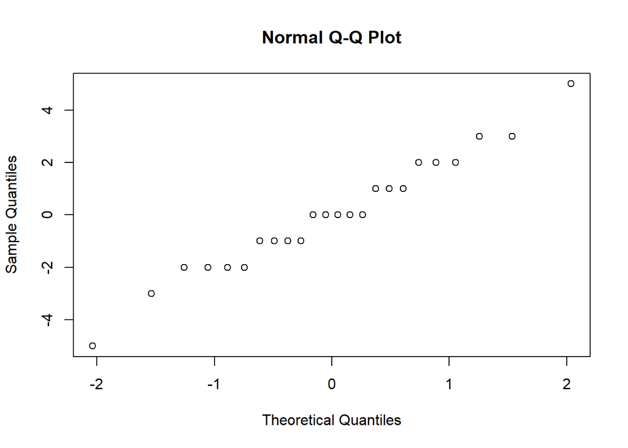

```r
qqnorm(g$res)
```

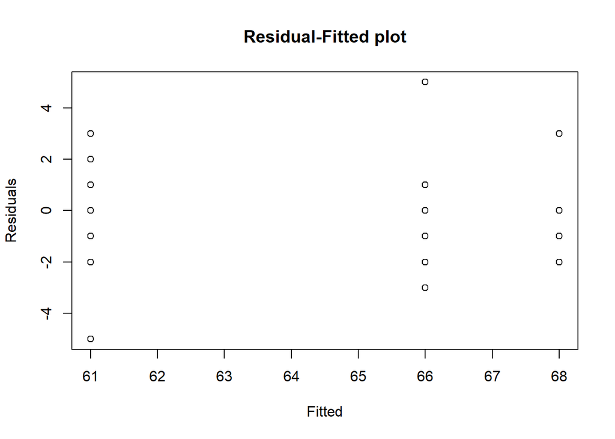

```r
plot(g$fit,g$res,xlab="Fitted",ylab="Residuals",
main="Residual-Fitted plot")
```

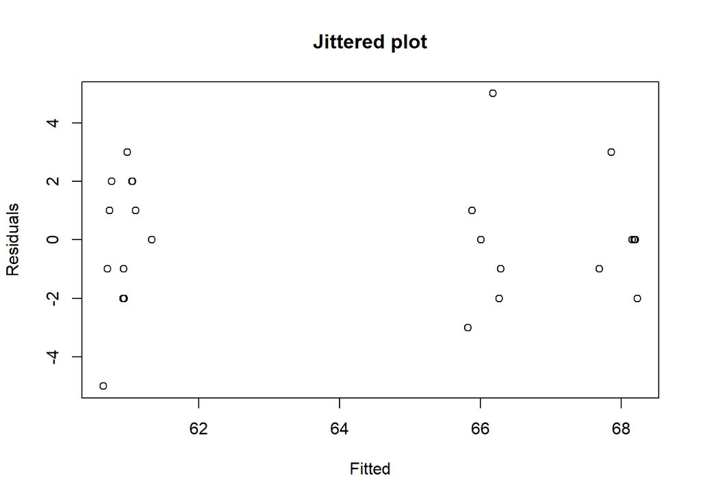

```r
plot(jitter(g$fit),g$res,xlab="Fitted",ylab="Residuals",
main="Jittered plot")
```

Поскольку данные являются целыми числами, и оценки оказались целыми числами поэтому заметна некоторая дискретность в Q-Q графике. Конечно, дискретные данные не могут быть нормально распределены. Тем не менее, будем считать их приблизительно нормальными. Дискретность можно убрать с помощью приема называемым “jittering” (дрожь) -добавление небольшого количества шума к данным.

После обнаружения того, что уровни факторов различны необходимо определить , что это различие существенно. Причем это не означает, существенен ли сам уровень. Здесь различают попарное сравнение в этом случае используется обычный тест, основанный на распределении Стьюдента и сравнение множественное в этом случае требуется использовать поправку Bonferroni, где уровень значимости считается равным $\alpha/m$,где $m$ число сравнений. При увеличении $m$ распределение стремится к Studentized Range Distribution, и основанному на этом тесте Tukey.

### Тест Тьюки.

Tukey’s range test назваемый также в англоязычной литературе Tukey method, Tukey’s honest significance test, Tukey’s HSD (honest significant difference) test - статистический тест для одновременной проверки значимости всех возможных пар оценок средних значений $(\hat\mu _{i},\hat\mu_j),(1\leq i,j\leq n)$ основан на распределении Studentized Range Distribution.

Предположения Тьюки теста

- все наблюдения статистически независимы как внутри одной группы,так и между группами;
- группа наблюденний связанная со средним $\mu_i$ нормально распределена.
- дисперсия одинакова для всех групп (однородность дисперсии).

### Studentized Range Distribution (SRD)

Предположим имеется $n$ групп случайных величин по $k$ наблюдений в каждой группе. Случайные величины независимы и все одинаково нормально распределены $N(\mu,\sigma)$. Тогда распределение случайной величины
$$q=
\frac{y_{max}-y_{min}}{S\sqrt{2/k}}$$
называется Studentized Range Distribution (SRD).

Где $S^2$ - оценка дисперсии выборки

$y_{max},y_{min}$ - максимальная (соответственно минимальная) из оценок средних, полученных по каждой группе.

Сначала рассмотрим попарное сравнение для некоторой фиксированной пары $\hat\mu_i,\hat\mu_j$. Из сделанных предположений следует, что для оценок $\hat\mu_i,\hat\mu_j$ доверительный интервал заданного уровня $\alpha$ для разности $\hat\mu_i-\hat\mu_j$ вычисляется по формуле

$m$ - общее число наблюдений;

$I$ - число оцениваемых параметров

$J_i,J_j$ - число наблюдений в группе $i$ и $j$

Посмотрим на случайных данных. Пусть у нас есть 6 групп по 4 наблюдения в каждой группе, каждому наблюдению сопоставим случайное число со стандартным нормальным распределением. Понятно, что связи здесь никакой нет и все средние в группе одинаковы.

```r
x <- factor(rep(LETTERS[1:6],rep(4,6)))
x
```

```
##  [1] A A A A B B B B C C C C D D D D E E E E F F F F
## Levels: A B C D E F
```

Предположим, что никакой связи нет, что естественно, так все данные случайны, т.е. нулевая гипотеза о том, что все $\mu_i$ равны не отвергается

```r
rn <- rnorm(24)
g <- lm(rn ~ x)
gs <- summary(g)
```

Проверим являются ли все средние одинаковы.

```r
oneway.test(rn ~ x)
```

```
##
##  One-way analysis of means (not assuming equal variances)
##
## data:  rn and x
## F = 2.8321, num df = 5.0000, denom df = 8.3137, p-value = 0.08908
```

Оценки

```r
gs$coef
```

```
##                Estimate Std. Error    t value  Pr(>|t|)
## (Intercept)  0.07071774  0.5132688  0.1377791 0.8919445
## xB          -0.74018349  0.7258717 -1.0197167 0.3213737
## xC           0.65677666  0.7258717  0.9048110 0.3775172
## xD          -1.00941772  0.7258717 -1.3906283 0.1812933
## xE           1.09307971  0.7258717  1.5058856 0.1494440
## xF           0.32590071  0.7258717  0.4489784 0.6588059
```

t-статистика для проверки гипотезы уровнь A = уровень B
$$\hat\sigma\sqrt{1/4+1/4}$$

```r
g$coef[2]*sqrt(2)/gs$sig
```

```
##        xB
## -1.019717
```

квантиль уровня 5%. Так как количество оцениваемых параметров равно $I=6$, то число степеней свободы будет 24-6

```r
qt(0.975,24-6)
```

```
## [1] 2.100922
```

Из всех возможных парных сравнений , мы можем вычислить максимальную и минимальную оценку среднего и вычислить Т-статистику как

```r
range(c(0,g$coef[-1]))
```

```
## [1] -1.009418  1.093080
```

```r
rg <- range(c(0,g$coef[-1]))
(rg[2]-rg[1])*sqrt(2)/gs$sig
```

```
## [1] 2.896514
```

,что больше, чем квантиль , нулевая гипотеза о не значимости отвергается. Теперь давайте повторим эксперимент в 1000 раз и посмотрим долю тех случаев, где гипотеза отвергается.

```r
res <- matrix(0,1000,2)
for(i in 1:1000)
  {
g <- lm(rnorm(24) ~ x)
gs <- summary(g)
res[i,1] <- abs(g$coef[2]*sqrt(2)/gs$sig)
rg <- range(c(0,g$coef[-1]))
res[i,2] <- (rg[2]-rg[1])*sqrt(2)/gs$sig
}
sum(res[,1] > 2.1)/1000
```

```
## [1] 0.055
```

```r
sum(res[,2] > 2.1)/1000
```

```
## [1] 0.314
```

Таким образом, в тех случаях, когда нет никакой разницы между уровнями фактора , в более, чем 30% случаев из всех 1000 опытов , исследователь сделает вывод ,что статистически значимую разницу между некоторыми уровнями фактора существует. Итак, если мы будем использовать обычное распределение Стьюдента, то существует большая опасность того, что можно будет сделать ошибочный вывод, что есть разница , когда ее в действительности не существует. Таким образом критическое значение необходимо увеличить, чтобы отвергать гипотезу не чаще, чем в 5% случаев. По результатам моделирования это число должно быть в районе

```r
quantile(res[,2],0.95)
```

```
##      95%
## 3.123937
```

Почти такое значение и дает метод Тьюки

```r
qtukey(0.95,6,18)/sqrt(2)
```

```
## [1] 3.178035
```

Посмотрим на плотности распределений статистик в нашем опыте с моделированием

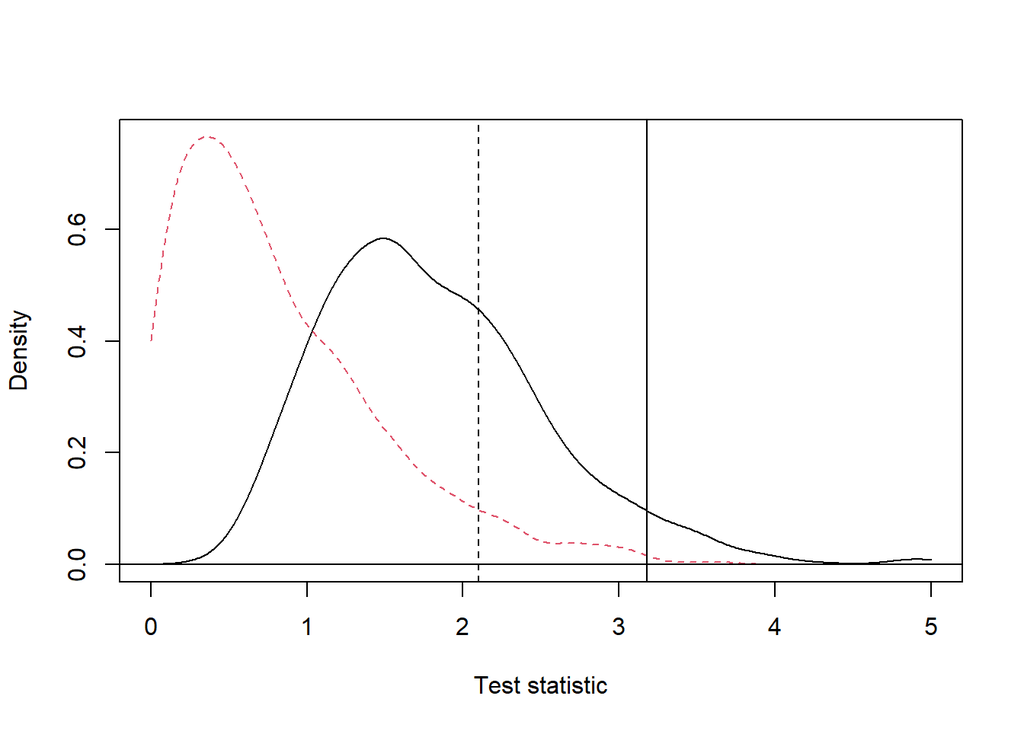

```r
dmax <- density(res[,2],from=0,to=5)
d2 <- density(res[,1],from=0,to=5)
matplot(d2$x,cbind(dmax$y,d2$y),type="l",xlab="Test statistic",
ylab="Density")
abline(h=0)
abline(v=2.1,lty=2)
abline(v=3.178)
```

Мы видим, что распределение статистики при проверке множественной гипотезы имеет гораздо тяжелее хвост, чем распределение статистики для наперед заданной пары.

Вернемся к нашему примеру с реальными данными Мы заметим, что существует значительная разница между диетами. Определим диеты, где различие между диетами существенны и где не существенны. Посмотрим расчеты для разницы между диетой B и C диеты , которая равна 2.

```r
qt(1-.05/2,20)*2.366*sqrt(1/6+1/6)
```

```
## [1] 2.849448
```

```r
c(2-2.85,2+2.85)
```

```
## [1] -0.85  4.85
```

Это доверительный интервал для разности между диетами B и С. Альтернативным способом мы можем сделать те же самые вычисления, если фактор B возьмем в качестве опорного уровня.

```r
coagulation$diet <- relevel(coagulation$diet,ref="B")
g <- lm(coag ~ diet, coagulation)
summary(g)
```

```
##
## Call:
## lm(formula = coag ~ diet, data = coagulation)
##
## Residuals:
##    Min     1Q Median     3Q    Max
##  -5.00  -1.25   0.00   1.25   5.00
##
## Coefficients:
##             Estimate Std. Error t value Pr(>|t|)
## (Intercept)  66.0000     0.9661  68.316  < 2e-16 ***
## dietA        -5.0000     1.5275  -3.273 0.003803 **
## dietC         2.0000     1.3663   1.464 0.158776
## dietD        -5.0000     1.2780  -3.912 0.000864 ***
## ---
## Signif. codes:  0 '***' 0.001 '**' 0.01 '*' 0.05 '.' 0.1 ' ' 1
##
## Residual standard error: 2.366 on 20 degrees of freedom
## Multiple R-squared:  0.6706, Adjusted R-squared:  0.6212
## F-statistic: 13.57 on 3 and 20 DF,  p-value: 4.658e-05
```

Удобный метод получения всех интервалов для всех попарных сравнений это

```r
 TukeyHSD(aov(coag ~ diet, coagulation))
```

```
##   Tukey multiple comparisons of means
##     95% family-wise confidence level
##
## Fit: aov(formula = coag ~ diet, data = coagulation)
##
## $diet
##     diff        lwr        upr     p adj
## A-B   -5  -9.275446 -0.7245544 0.0183283
## C-B    2  -1.824075  5.8240748 0.4766005
## D-B   -5  -8.577094 -1.4229056 0.0044114
## C-A    7   2.724554 11.2754456 0.0009577
## D-A    0  -4.056044  4.0560438 1.0000000
## D-C   -7 -10.577094 -3.4229056 0.0001268
```

Также удобным тестом для проверки, являются ли все средние одинаковы дает метод.

```r
oneway.test(coag ~ diet, coagulation)
```

```
##
##  One-way analysis of means (not assuming equal variances)
##
## data:  coag and diet
## F = 16.728, num df = 3.0000, denom df = 9.9533, p-value = 0.0003249
```

### Двух факторный ANOVA

Пусть теперь у нас два фактора $\alpha$ и $\beta$, $J$ уровней и $n_{i,j}$ $i$-aя группа на уровне $\alpha$, $j$-aя группа наблюдений на уровне $\beta$ и $y_{i,j,1},y_{i,j,2},...$ наблюдения. Будем предполагать, что $n_{i,j}>1$. Модель задается следующим выражением
$$y_{i,j,k}=\mu+\alpha_i+\beta_j+\alpha_i\beta_j+\epsilon_{i,j,k}$$

Член $\alpha_i\beta_j$ интерпретируется как часть уровня $\alpha_i$ и часть $\beta_j$, но не обоих сразу или наоборот обоих. Например любить клубнику и сливки отдельно, но вместе лучше. Или наоборот любить рыбу и мороженое, но не одновременно. Этот эффект взаимодействия может быть проверен путем сравнения результатов оценивания с моделью
$$y_{i,j,k}=\mu+\alpha_i+\beta_j+\epsilon_{i,j,k}$$
Для примера рассмотрим пример с крысами. 48 наблюдений над крысами на следующих 3-х переменных.

время - продолжительность жизни в десятках часов;

тип яда - фактор с уровнями I II III;

лечение - фактор с уровнями A,B,C,D.

```r
data(rats)
head(rats)
```

```
##   time poison treat
## 1 0.31      I     A
## 2 0.82      I     B
## 3 0.43      I     C
## 4 0.45      I     D
## 5 0.45      I     A
## 6 1.10      I     B
```

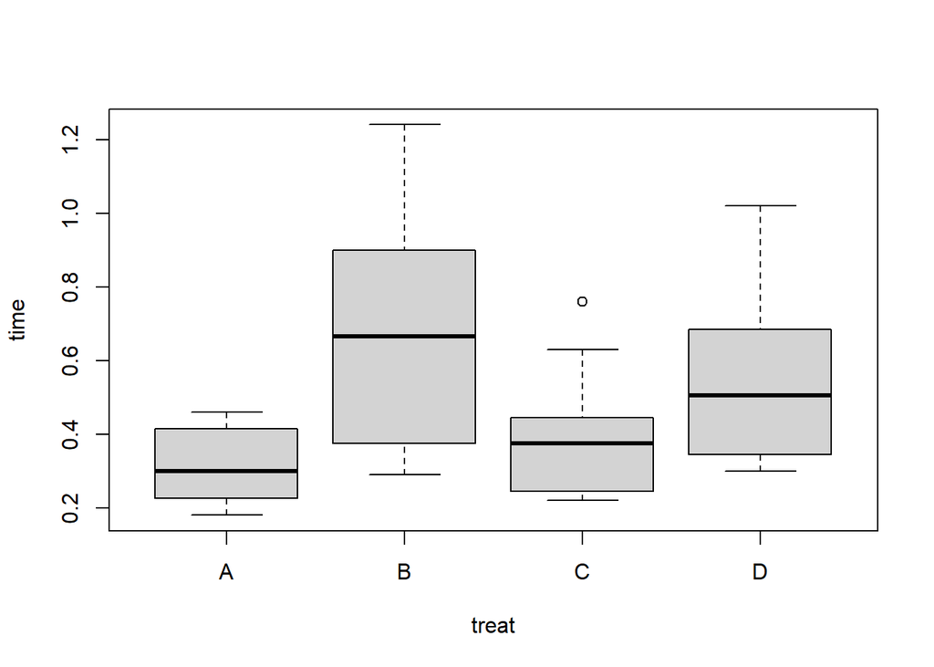

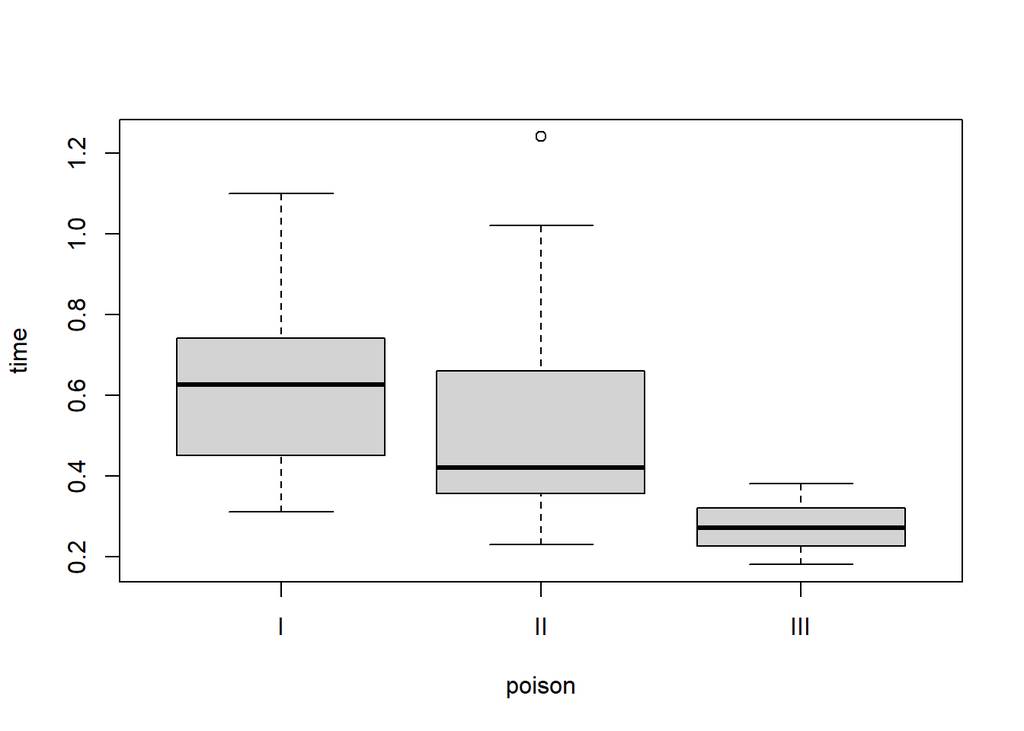

```r
plot(time ~ treat + poison, data=rats)
```

Посмотрим есть ли эффект взаимодействия графически на среднее

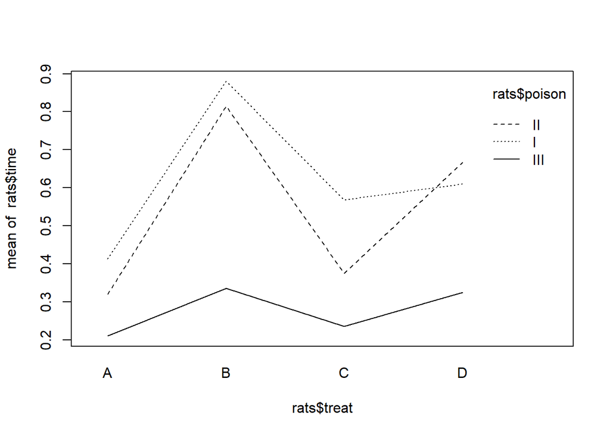

```r
interaction.plot(rats$treat,rats$poison,rats$time)
```

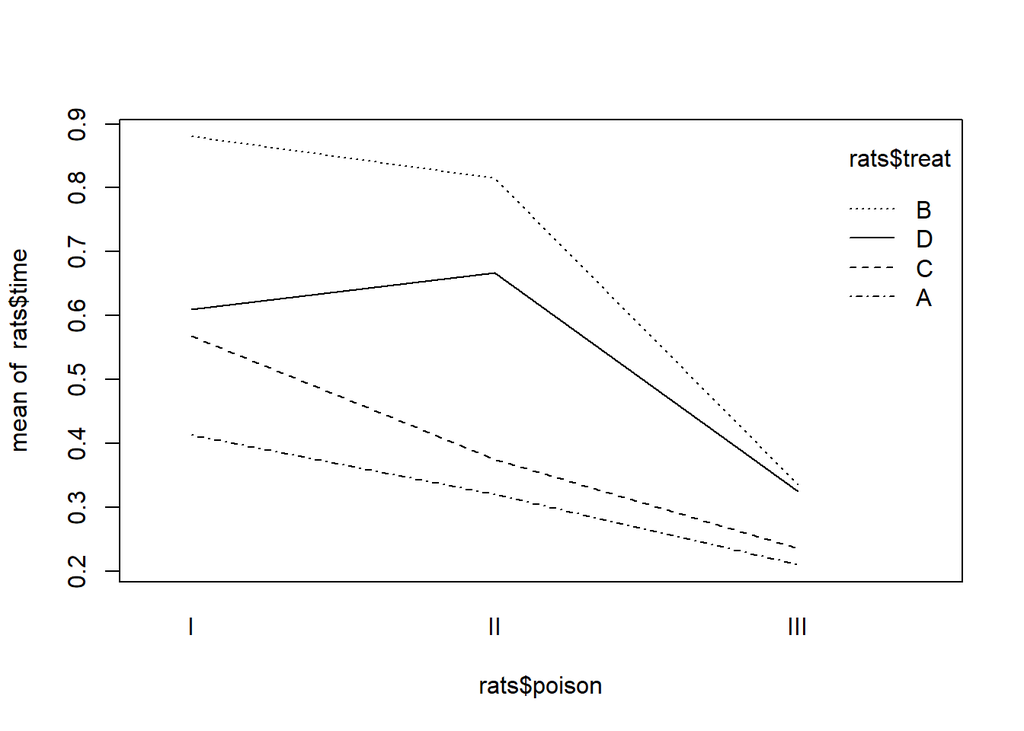

```r
interaction.plot(rats$poison,rats$treat,rats$time)
```

По графикам трудно сказать о значимости взаимодействия. Но можно это и численно проверить.

```r
g <- lm(time ~ poison*treat, rats)
anova(g)
```

```
## Analysis of Variance Table
##
## Response: time
##              Df  Sum Sq Mean Sq F value    Pr(>F)
## poison        2 1.03301 0.51651 23.2217 3.331e-07 ***
## treat         3 0.92121 0.30707 13.8056 3.777e-06 ***
## poison:treat  6 0.25014 0.04169  1.8743    0.1123
## Residuals    36 0.80073 0.02224
## ---
## Signif. codes:  0 '***' 0.001 '**' 0.01 '*' 0.05 '.' 0.1 ' ' 1
```

Эффект взаимодействия не значим. Основные факторы значимы. Посмотрим на остатки.

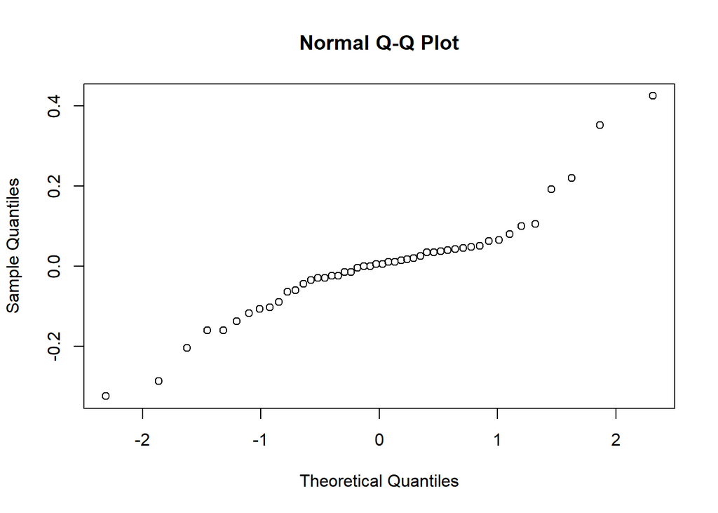

```r
qqnorm(g$res)
```

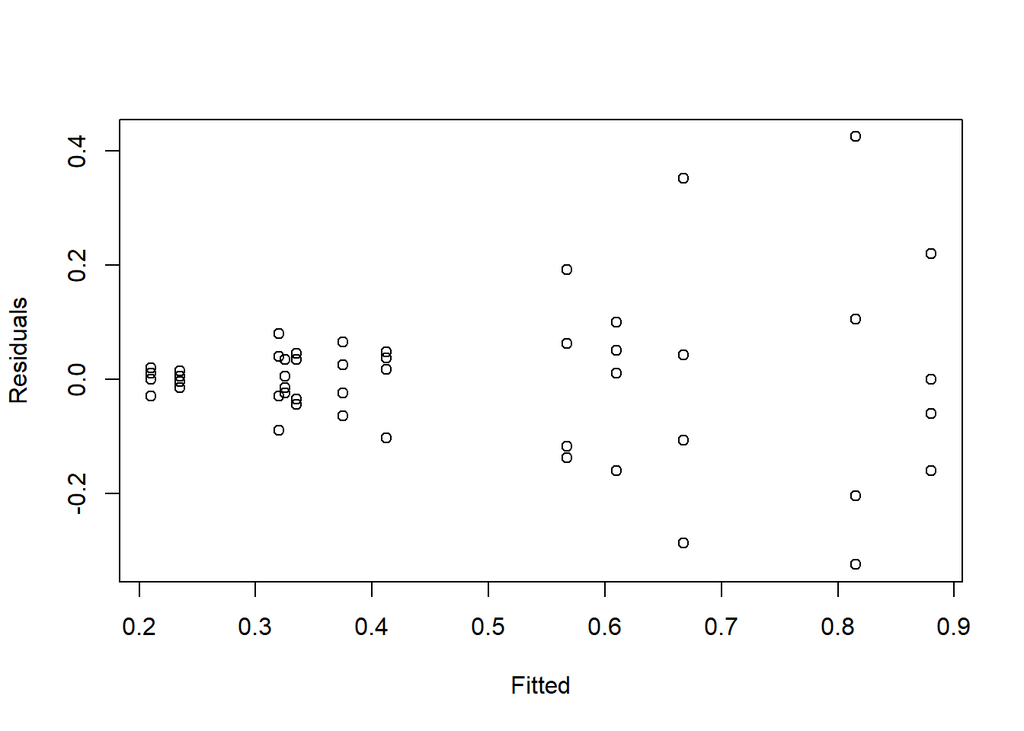

```r
plot(g$fitted,g$res,xlab="Fitted",ylab="Residuals")
```

Распределение остатков явно отлично от нормального. И из второго графика проглядывается корреляция. Чтобы не упустить эффект взаимодействия попробуем преобразовать данные. Начнем с логарифма.

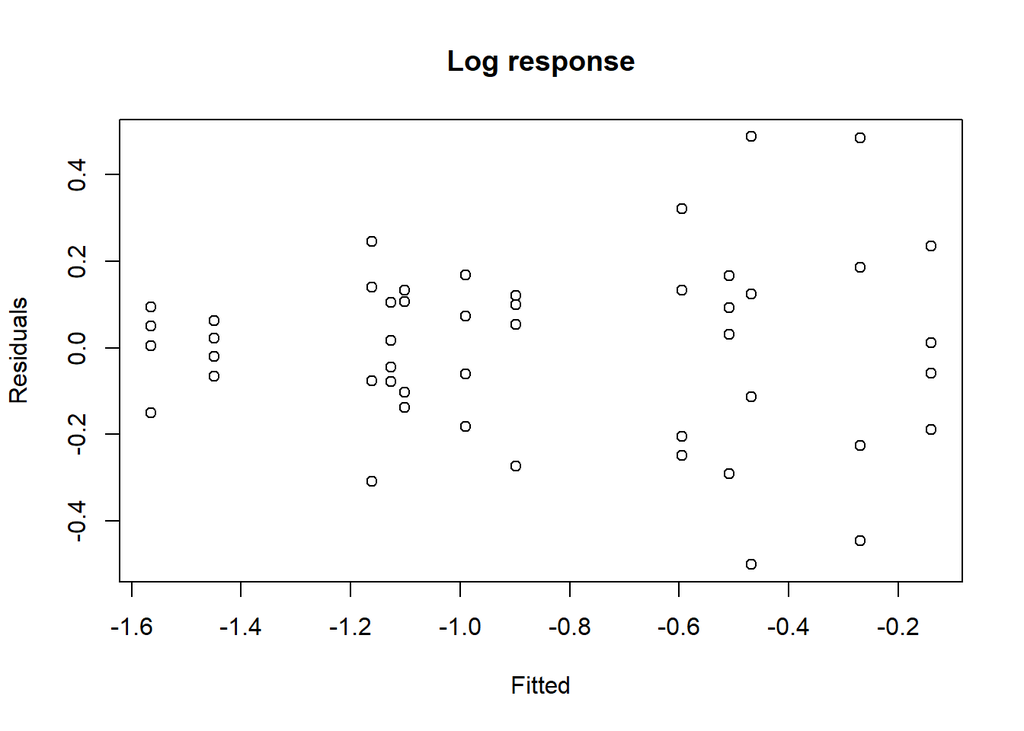

```r
g <- lm(log(time) ~ poison*treat,rats)
plot(g$fitted,g$res,xlab="Fitted",ylab="Residuals",main="Log response")
```

```r
anova(g)
```

```
## Analysis of Variance Table
##
## Response: log(time)
##              Df Sum Sq Mean Sq F value    Pr(>F)
## poison        2 5.2375 2.61874 48.4324 6.195e-11 ***
## treat         3 3.5572 1.18572 21.9295 2.987e-08 ***
## poison:treat  6 0.3957 0.06596  1.2199    0.3189
## Residuals    36 1.9465 0.05407
## ---
## Signif. codes:  0 '***' 0.001 '**' 0.01 '*' 0.05 '.' 0.1 ' ' 1
```

Этого оказалось недостаточно.

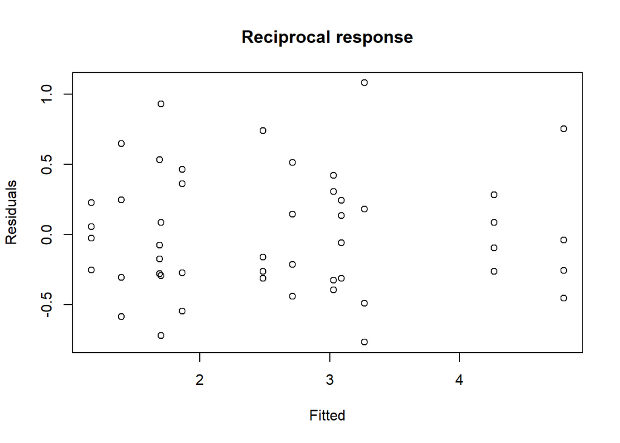

```r
g <- lm(1/time ~ poison*treat,rats)
plot(g$fitted,g$res,xlab="Fitted",ylab="Residuals",
main="Reciprocal response")
```

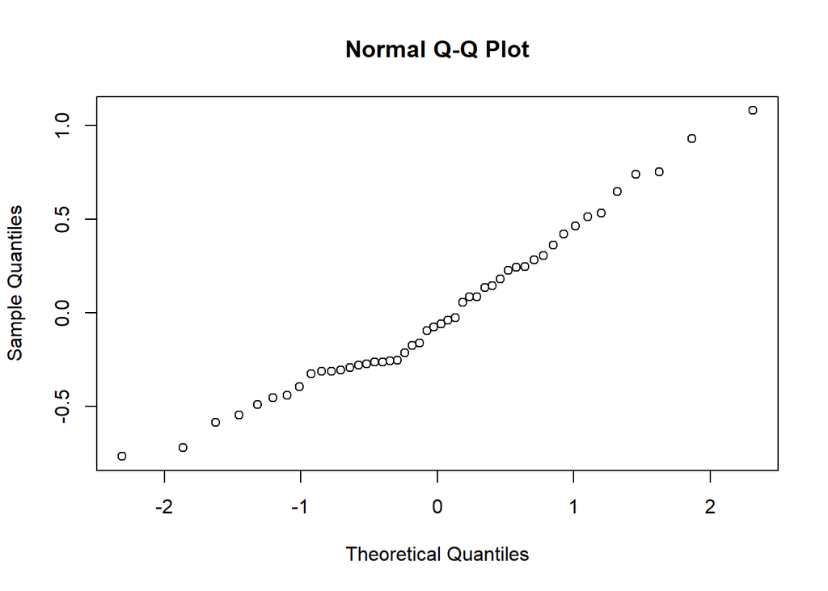

```r
qqnorm(g$res)
```

Стало лучше особоенно Q-Q график Посмотрим на оценки параметров

```r
anova(g)
```

```
## Analysis of Variance Table
##
## Response: 1/time
##              Df Sum Sq Mean Sq F value    Pr(>F)
## poison        2 34.877 17.4386 72.6347 2.310e-13 ***
## treat         3 20.414  6.8048 28.3431 1.376e-09 ***
## poison:treat  6  1.571  0.2618  1.0904    0.3867
## Residuals    36  8.643  0.2401
## ---
## Signif. codes:  0 '***' 0.001 '**' 0.01 '*' 0.05 '.' 0.1 ' ' 1
```

Эффект взаимодействия все равно не значим. Оценим модель без него.

```r
g <- lm(1/time ~ poison +treat , rats)
summary(g)
```

```
##
## Call:
## lm(formula = 1/time ~ poison + treat, data = rats)
##
## Residuals:
##      Min       1Q   Median       3Q      Max
## -0.82757 -0.37619  0.02116  0.27568  1.18153
##
## Coefficients:
##             Estimate Std. Error t value Pr(>|t|)
## (Intercept)   2.6977     0.1744  15.473  < 2e-16 ***
## poisonII      0.4686     0.1744   2.688  0.01026 *
## poisonIII     1.9964     0.1744  11.451 1.69e-14 ***
## treatB       -1.6574     0.2013  -8.233 2.66e-10 ***
## treatC       -0.5721     0.2013  -2.842  0.00689 **
## treatD       -1.3583     0.2013  -6.747 3.35e-08 ***
## ---
## Signif. codes:  0 '***' 0.001 '**' 0.01 '*' 0.05 '.' 0.1 ' ' 1
##
## Residual standard error: 0.4931 on 42 degrees of freedom
## Multiple R-squared:  0.8441, Adjusted R-squared:  0.8255
## F-statistic: 45.47 on 5 and 42 DF,  p-value: 6.974e-16
```

Все параметры значимы. Построим доверительный интервал для фактора лечение методом Тьюки.

```r
qtukey(0.95,4,42)*0.201/sqrt(2)
```

```
## [1] 0.5376664
```

Интервал будет разность плюс минус это число.Все пары кроме пары B-D не попадают в этот интервал. Отсюда вывод все эти пары лечений существенно различны. Самостоятельно проделайте вычисления для ядов.

```r
Students <-read.csv("./ANOVA.csv",sep = ",")
Students <-Students[Students$EGE> 0,]
head(Students)
```

```
##           X DVI EGE ALGEBRA GEOM
## 1  АХМЕТОВА 100 100      AA   GA
## 3  САМСОНОВ 100 100      AA   GB
## 4  СТЕПАНЮК  80  90      AA   GB
## 5 НИКИФОРОВ  75  81      AA   GB
## 6  ХАБИРОВА 100  85      AA   GA
## 8    КОЗЛОВ 100  85      AA   GB
```

```r
#plot(EGE ~ ALGEBRA + GEOM, data=Students)
```

Произведем оценку линейной регрессии

```r
gs <- lm(EGE ~ ALGEBRA+GEOM,Students)
summary(gs)
```

```
##
## Call:
## lm(formula = EGE ~ ALGEBRA + GEOM, data = Students)
##
## Residuals:
##     Min      1Q  Median      3Q     Max
## -30.986  -4.986   2.072   6.129  21.014
##
## Coefficients:
##             Estimate Std. Error t value Pr(>|t|)
## (Intercept)  92.1850     4.4896  20.533  < 2e-16 ***
## ALGEBRAAB    -0.7433     2.3408  -0.318  0.75105
## ALGEBRAAC    -3.0914     2.2769  -1.358  0.17554
## ALGEBRAAD    -1.6488     2.2928  -0.719  0.47262
## ALGEBRAAE    -6.7764     2.3980  -2.826  0.00502 **
## ALGEBRAAF   -12.3979     2.5740  -4.817 2.28e-06 ***
## GEOMGB        2.0758     4.5724   0.454  0.65015
## GEOMGC        1.3346     4.5206   0.295  0.76802
## GEOMGD       -0.8011     4.5725  -0.175  0.86103
## ---
## Signif. codes:  0 '***' 0.001 '**' 0.01 '*' 0.05 '.' 0.1 ' ' 1
##
## Residual standard error: 8.712 on 313 degrees of freedom
## Multiple R-squared:  0.1869, Adjusted R-squared:  0.1661
## F-statistic: 8.991 on 8 and 313 DF,  p-value: 4.105e-11
```

Cтатистика R-квадрат маленькая. Следовательно корреляция результатов контрольных и ЕГЭ очень небольшая.

Посмотрим на влияние алгебры и геометрии на результат ЕГЭ

```r
anova(gs)
```

```
## Analysis of Variance Table
##
## Response: EGE
##            Df  Sum Sq Mean Sq F value    Pr(>F)
## ALGEBRA     5  5087.4 1017.49 13.4067 7.461e-12 ***
## GEOM        3   371.7  123.89  1.6324    0.1818
## Residuals 313 23754.9   75.89
## ---
## Signif. codes:  0 '***' 0.001 '**' 0.01 '*' 0.05 '.' 0.1 ' ' 1
```

Результаты геометрии не значимы. Произведем оценку модели без геометрии

```r
as <- lm(EGE ~ ALGEBRA,Students)
gs<- summary(as)
gs$sigma
```

```
## [1] 8.737839
```

```r
#plot(EGE ~ ALGEBRA,Students)
```

Если оценим без константы, то оценим сами средние по группам

```r
as1 <- lm(EGE ~ ALGEBRA-1,Students)
summary(as1)
```

```
##
## Call:
## lm(formula = EGE ~ ALGEBRA - 1, data = Students)
##
## Residuals:
##     Min      1Q  Median      3Q     Max
## -31.892  -5.509   2.152   6.300  20.108
##
## Coefficients:
##           Estimate Std. Error t value Pr(>|t|)
## ALGEBRAAA  93.6500     1.9538   47.93   <2e-16 ***
## ALGEBRAAB  92.5088     1.1574   79.93   <2e-16 ***
## ALGEBRAAC  89.8481     0.9831   91.39   <2e-16 ***
## ALGEBRAAD  91.2468     0.9958   91.63   <2e-16 ***
## ALGEBRAAE  86.0769     1.2117   71.04   <2e-16 ***
## ALGEBRAAF  79.8919     1.4365   55.62   <2e-16 ***
## ---
## Signif. codes:  0 '***' 0.001 '**' 0.01 '*' 0.05 '.' 0.1 ' ' 1
##
## Residual standard error: 8.738 on 316 degrees of freedom
## Multiple R-squared:  0.9907, Adjusted R-squared:  0.9905
## F-statistic:  5596 on 6 and 316 DF,  p-value: < 2.2e-16
```

Проверим являются ли все средние одинаковы.

```r
oneway.test(EGE ~ ALGEBRA,Students)
```

```
##
##  One-way analysis of means (not assuming equal variances)
##
## data:  EGE and ALGEBRA
## F = 8.1534, num df = 5.00, denom df = 106.37, p-value = 1.517e-06
```

Проверим все попарные средние по методу Тьюки

```r
 TukeyHSD(aov(EGE ~ ALGEBRA,Students))
```

```
##   Tukey multiple comparisons of means
##     95% family-wise confidence level
##
## Fit: aov(formula = EGE ~ ALGEBRA, data = Students)
##
## $ALGEBRA
##             diff        lwr        upr     p adj
## AB-AA  -1.141228  -7.652550  5.3700938 0.9960564
## AC-AA  -3.801899 -10.073310  2.4695125 0.5075336
## AD-AA  -2.403247  -8.691090  3.8845969 0.8828176
## AE-AA  -7.573077 -14.165208 -0.9809463 0.0139051
## AF-AA -13.758108 -20.711517 -6.8046988 0.0000005
## AC-AB  -2.660671  -7.014734  1.6933923 0.4983926
## AD-AB  -1.262019  -5.639717  3.1156797 0.9624533
## AE-AB  -6.431849 -11.236373 -1.6273247 0.0020578
## AF-AB -12.616880 -17.906225 -7.3275354 0.0000000
## AD-AC   1.398652  -2.613521  5.4108247 0.9178678
## AE-AC  -3.771178  -8.245185  0.7028288 0.1535290
## AF-AC  -9.956209 -14.947247 -4.9651721 0.0000004
## AE-AD  -5.169830  -9.666842 -0.6728181 0.0138012
## AF-AD -11.354861 -16.366531 -6.3431918 0.0000000
## AF-AE  -6.185031 -11.573541 -0.7965211 0.0140328
```

То, что контрольная по геометрии вместе с контрольной по алгебре малозначима для сравнения уровней оценки по ЕГЭ можно увидеть из следующего теста

```r
TukeyHSD(aov(EGE ~ ALGEBRA+ GEOM,Students))
```

```
##   Tukey multiple comparisons of means
##     95% family-wise confidence level
##
## Fit: aov(formula = EGE ~ ALGEBRA + GEOM, data = Students)
##
## $ALGEBRA
##             diff        lwr        upr     p adj
## AB-AA  -1.141228  -7.633475  5.3510193 0.9959999
## AC-AA  -3.801899 -10.054938  2.4511408 0.5041181
## AD-AA  -2.403247  -8.672671  3.8661771 0.8814874
## AE-AA  -7.573077 -14.145896 -1.0002575 0.0134796
## AF-AA -13.758108 -20.691148 -6.8250683 0.0000004
## AC-AB  -2.660671  -7.001979  1.6806374 0.4949621
## AD-AB  -1.262019  -5.626893  3.1028555 0.9619686
## AE-AB  -6.431849 -11.222298 -1.6413993 0.0019735
## AF-AB -12.616880 -17.890730 -7.3430302 0.0000000
## AD-AC   1.398652  -2.601767  5.3990713 0.9168869
## AE-AC  -3.771178  -8.232079  0.6897225 0.1511139
## AF-AC  -9.956209 -14.932626 -4.9797930 0.0000003
## AE-AD  -5.169830  -9.653668 -0.6859918 0.0133783
## AF-AD -11.354861 -16.351850 -6.3578731 0.0000000
## AF-AE  -6.185031 -11.557756 -0.8123064 0.0136041
##
## $GEOM
##             diff        lwr        upr     p adj
## GB-GA  2.2547142  -9.397919 13.9073478 0.9590716
## GC-GA  1.6649061  -9.726430 13.0562424 0.9816425
## GD-GA -0.3359959 -11.801011 11.1290194 0.9998442
## GC-GB -0.5898080  -4.109757  2.9301412 0.9727964
## GD-GB -2.5907100  -6.342253  1.1608334 0.2831160
## GD-GC -2.0009020  -4.838639  0.8368345 0.2652647
```

Посмотрим на остатки после оценки модели только с алгеброй. Это также ответит на вопрос о справедливости предположений для применимости ANOVA к этим данным(нормальность, однородность дисперсии).

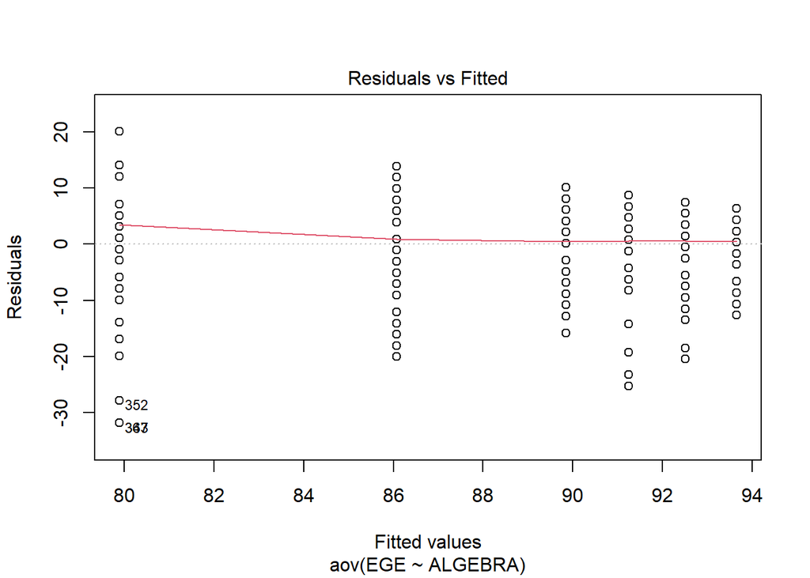

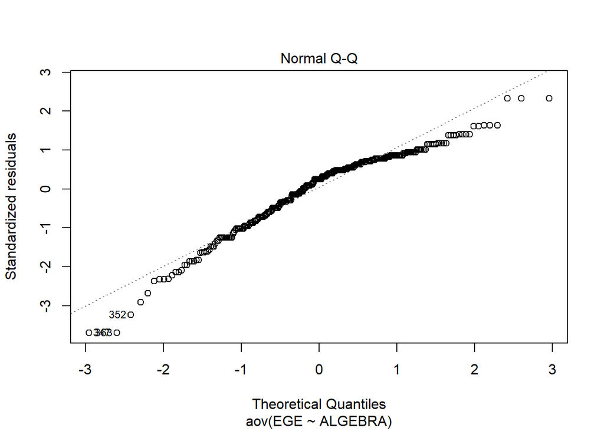

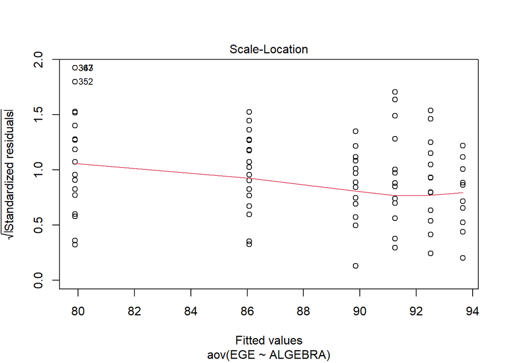

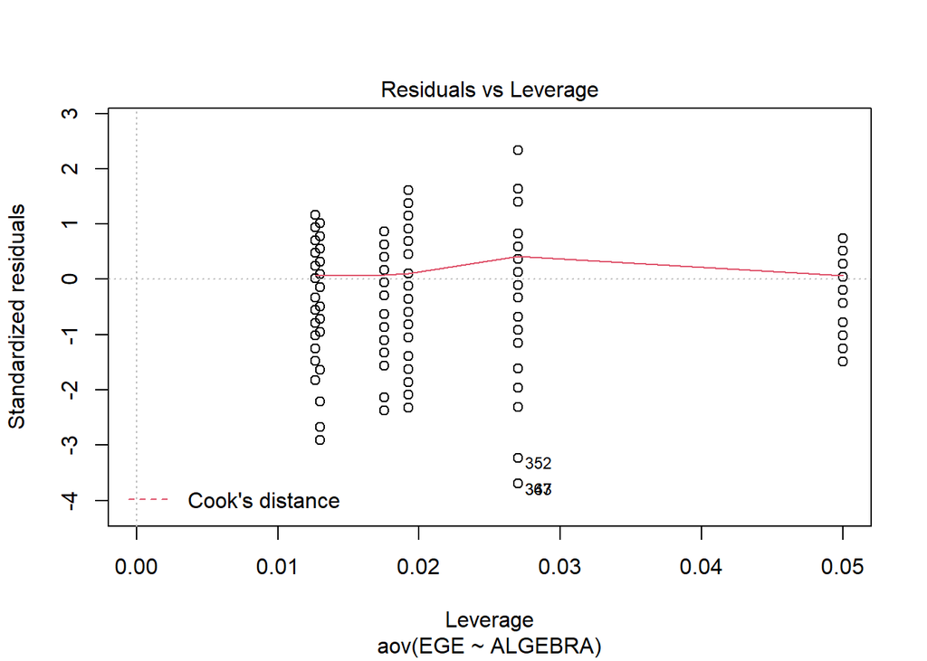

```r
ouv.out <- aov(EGE ~ ALGEBRA,Students)
plot(ouv.out)
```